# Risk Factor Analysis

## Outcome Variable

**Outcome Variable:** stunted

## Predictor Variables

**Intervention Variable:** hfoodsec

**Adjustment Set:**

- arm
- sex
- W_mage
- meducyrs
- feducyrs
- hhwealth_quart
- vagbrth
- W_nrooms
- W_nchldlt5
- brthmon
- W_parity
- impfloor
- impsan
- safeh20
- delta_W_mage
- delta_meducyrs
- delta_feducyrs
- delta_hhwealth_quart
- delta_vagbrth
- delta_W_nrooms
- delta_W_nchldlt5
- delta_brthmon
- delta_W_parity
- delta_impfloor
- delta_impsan
- delta_safeh20

## Stratifying Variables

The analysis was stratified on these variable(s):

- agecat
- studyid
- country

## Data Summary

| agecat | studyid | country | hfoodsec | stunted | n_cell | n |
| --- | --- | --- | --- | --- | --- | --- |
| Birth | ki0047075b-MAL-ED | BANGLADESH | Food Secure | 0 | 121 | 172 |
| Birth | ki0047075b-MAL-ED | BANGLADESH | Food Secure | 1 | 23 | 172 |
| Birth | ki0047075b-MAL-ED | BANGLADESH | Mildly Food Insecure | 0 | 3 | 172 |
| Birth | ki0047075b-MAL-ED | BANGLADESH | Mildly Food Insecure | 1 | 1 | 172 |
| Birth | ki0047075b-MAL-ED | BANGLADESH | Food Insecure | 0 | 19 | 172 |
| Birth | ki0047075b-MAL-ED | BANGLADESH | Food Insecure | 1 | 5 | 172 |
| Birth | ki0047075b-MAL-ED | BRAZIL | Food Secure | 0 | 0 | 28 |
| Birth | ki0047075b-MAL-ED | BRAZIL | Food Secure | 1 | 0 | 28 |
| Birth | ki0047075b-MAL-ED | BRAZIL | Mildly Food Insecure | 0 | 3 | 28 |
| Birth | ki0047075b-MAL-ED | BRAZIL | Mildly Food Insecure | 1 | 1 | 28 |
| Birth | ki0047075b-MAL-ED | BRAZIL | Food Insecure | 0 | 20 | 28 |
| Birth | ki0047075b-MAL-ED | BRAZIL | Food Insecure | 1 | 4 | 28 |
| Birth | ki0047075b-MAL-ED | INDIA | Food Secure | 0 | 28 | 37 |
| Birth | ki0047075b-MAL-ED | INDIA | Food Secure | 1 | 6 | 37 |
| Birth | ki0047075b-MAL-ED | INDIA | Mildly Food Insecure | 0 | 1 | 37 |
| Birth | ki0047075b-MAL-ED | INDIA | Mildly Food Insecure | 1 | 0 | 37 |
| Birth | ki0047075b-MAL-ED | INDIA | Food Insecure | 0 | 1 | 37 |
| Birth | ki0047075b-MAL-ED | INDIA | Food Insecure | 1 | 1 | 37 |
| Birth | ki0047075b-MAL-ED | NEPAL | Food Secure | 0 | 10 | 14 |
| Birth | ki0047075b-MAL-ED | NEPAL | Food Secure | 1 | 0 | 14 |
| Birth | ki0047075b-MAL-ED | NEPAL | Mildly Food Insecure | 0 | 1 | 14 |
| Birth | ki0047075b-MAL-ED | NEPAL | Mildly Food Insecure | 1 | 0 | 14 |
| Birth | ki0047075b-MAL-ED | NEPAL | Food Insecure | 0 | 3 | 14 |
| Birth | ki0047075b-MAL-ED | NEPAL | Food Insecure | 1 | 0 | 14 |
| Birth | ki0047075b-MAL-ED | PERU | Food Secure | 0 | 20 | 91 |
| Birth | ki0047075b-MAL-ED | PERU | Food Secure | 1 | 4 | 91 |
| Birth | ki0047075b-MAL-ED | PERU | Mildly Food Insecure | 0 | 21 | 91 |
| Birth | ki0047075b-MAL-ED | PERU | Mildly Food Insecure | 1 | 2 | 91 |
| Birth | ki0047075b-MAL-ED | PERU | Food Insecure | 0 | 39 | 91 |
| Birth | ki0047075b-MAL-ED | PERU | Food Insecure | 1 | 5 | 91 |

[output cut: 168 more lines]

The following strata were considered:

- agecat: 24 months, studyid: ki0047075b-MAL-ED, country: BANGLADESH
- agecat: 24 months, studyid: ki0047075b-MAL-ED, country: BRAZIL
- agecat: 24 months, studyid: ki0047075b-MAL-ED, country: INDIA
- agecat: 24 months, studyid: ki0047075b-MAL-ED, country: NEPAL
- agecat: 24 months, studyid: ki0047075b-MAL-ED, country: PERU
- agecat: 24 months, studyid: ki0047075b-MAL-ED, country: SOUTH AFRICA
- agecat: 24 months, studyid: ki1017093-NIH-Birth, country: BANGLADESH
- agecat: 24 months, studyid: ki1017093c-NIH-Crypto, country: BANGLADESH
- agecat: 24 months, studyid: ki1113344-GMS-Nepal, country: NEPAL
- agecat: 24 months, studyid: kiGH5241-JiVitA-3, country: BANGLADESH
- agecat: 24 months, studyid: kiGH5241-JiVitA-4, country: BANGLADESH
- agecat: 6 months, studyid: ki0047075b-MAL-ED, country: BANGLADESH
- agecat: 6 months, studyid: ki0047075b-MAL-ED, country: BRAZIL
- agecat: 6 months, studyid: ki0047075b-MAL-ED, country: INDIA
- agecat: 6 months, studyid: ki0047075b-MAL-ED, country: NEPAL
- agecat: 6 months, studyid: ki0047075b-MAL-ED, country: PERU
- agecat: 6 months, studyid: ki0047075b-MAL-ED, country: SOUTH AFRICA
- agecat: 6 months, studyid: ki1017093-NIH-Birth, country: BANGLADESH
- agecat: 6 months, studyid: ki1017093c-NIH-Crypto, country: BANGLADESH
- agecat: 6 months, studyid: ki1113344-GMS-Nepal, country: NEPAL
- agecat: 6 months, studyid: kiGH5241-JiVitA-3, country: BANGLADESH
- agecat: 6 months, studyid: kiGH5241-JiVitA-4, country: BANGLADESH
- agecat: Birth, studyid: ki0047075b-MAL-ED, country: BANGLADESH
- agecat: Birth, studyid: ki0047075b-MAL-ED, country: BRAZIL
- agecat: Birth, studyid: ki0047075b-MAL-ED, country: INDIA
- agecat: Birth, studyid: ki0047075b-MAL-ED, country: NEPAL
- agecat: Birth, studyid: ki0047075b-MAL-ED, country: PERU
- agecat: Birth, studyid: ki0047075b-MAL-ED, country: SOUTH AFRICA
- agecat: Birth, studyid: ki1017093-NIH-Birth, country: BANGLADESH
- agecat: Birth, studyid: ki1017093c-NIH-Crypto, country: BANGLADESH
- agecat: Birth, studyid: ki1113344-GMS-Nepal, country: NEPAL
- agecat: Birth, studyid: kiGH5241-JiVitA-3, country: BANGLADESH
- agecat: Birth, studyid: kiGH5241-JiVitA-4, country: BANGLADESH

### Dropped Strata

Some strata were dropped due to rare outcomes:

- agecat: Birth, studyid: ki0047075b-MAL-ED, country: BANGLADESH
- agecat: Birth, studyid: ki0047075b-MAL-ED, country: BRAZIL
- agecat: Birth, studyid: ki0047075b-MAL-ED, country: INDIA
- agecat: Birth, studyid: ki0047075b-MAL-ED, country: NEPAL
- agecat: Birth, studyid: ki0047075b-MAL-ED, country: PERU
- agecat: Birth, studyid: ki0047075b-MAL-ED, country: SOUTH AFRICA
- agecat: 6 months, studyid: ki0047075b-MAL-ED, country: BANGLADESH
- agecat: 6 months, studyid: ki0047075b-MAL-ED, country: BRAZIL
- agecat: 6 months, studyid: ki0047075b-MAL-ED, country: INDIA
- agecat: 6 months, studyid: ki0047075b-MAL-ED, country: NEPAL
- agecat: 6 months, studyid: ki0047075b-MAL-ED, country: SOUTH AFRICA
- agecat: 24 months, studyid: ki0047075b-MAL-ED, country: BANGLADESH
- agecat: 24 months, studyid: ki0047075b-MAL-ED, country: BRAZIL
- agecat: 24 months, studyid: ki0047075b-MAL-ED, country: INDIA
- agecat: 24 months, studyid: ki0047075b-MAL-ED, country: NEPAL

## Methods Detail

We’re interested in the causal parameters $E[Y_a]$ for all values of $a \in \mathcal{A}$. These parameters represent the mean outcome if, possibly contrary to fact, we intervened to set all units to have $A=a$. Under the randomization and positivity assumptions, these are identified by the statistical parameters $\psi_a=E_W[E_{Y|A,W}(Y|A=a,W)]$. In addition, we’re interested in the mean of $Y$, $E[Y]$ under no intervention (the observed mean). We will estimate these parameters by using SuperLearner to fit the relevant likelihood factors – $E_{Y|A,W}(Y|A=a,W)$ and $p(A=a|W)$, and then updating our likelihood fit using a joint TMLE.

For unadjusted analyses ($W=\{\}$), initial likelihoods were estimated using Lrnr_glm to estimate the simple $E(Y|A)$ and Lrnr_mean to estimate $p(A)$. For adjusted analyses, a small library containing Lrnr_glmnet, Lrnr_xgboost, and Lrnr_mean was used.

Having estimated these parameters, we will then use the delta method to estimate relative risks and attributable risks relative to a prespecified baseline level of $A$.

# Results Detail

## Results Plots

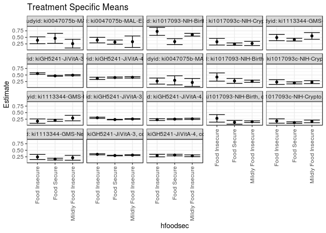

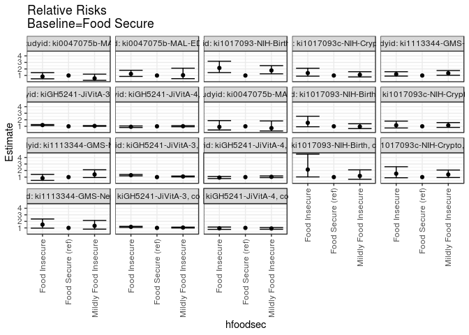

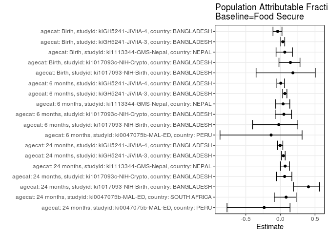

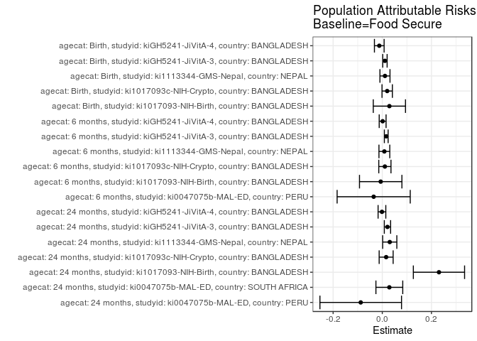

## Results Table

### Parameter: TSM

| agecat | studyid | country | intervention_level | baseline_level | estimate | ci_lower | ci_upper |
| --- | --- | --- | --- | --- | --- | --- | --- |
| Birth | ki1017093-NIH-Birth | BANGLADESH | Food Secure | NA | 0.1306905 | 0.0607158 | 0.2006651 |
| Birth | ki1017093-NIH-Birth | BANGLADESH | Mildly Food Insecure | NA | 0.1549237 | 0.1224063 | 0.1874412 |
| Birth | ki1017093-NIH-Birth | BANGLADESH | Food Insecure | NA | 0.2810902 | 0.1377052 | 0.4244751 |
| Birth | ki1017093c-NIH-Crypto | BANGLADESH | Food Secure | NA | 0.1180385 | 0.0877551 | 0.1483219 |
| Birth | ki1017093c-NIH-Crypto | BANGLADESH | Mildly Food Insecure | NA | 0.1647020 | 0.1142530 | 0.2151510 |
| Birth | ki1017093c-NIH-Crypto | BANGLADESH | Food Insecure | NA | 0.1800814 | 0.0970304 | 0.2631325 |
| Birth | ki1113344-GMS-Nepal | NEPAL | Food Secure | NA | 0.1617266 | 0.1279034 | 0.1955498 |
| Birth | ki1113344-GMS-Nepal | NEPAL | Mildly Food Insecure | NA | 0.2128819 | 0.1193202 | 0.3064436 |
| Birth | ki1113344-GMS-Nepal | NEPAL | Food Insecure | NA | 0.2438760 | 0.1473419 | 0.3404101 |
| Birth | kiGH5241-JiVitA-3 | BANGLADESH | Food Secure | NA | 0.3005041 | 0.2884722 | 0.3125360 |
| Birth | kiGH5241-JiVitA-3 | BANGLADESH | Mildly Food Insecure | NA | 0.3153170 | 0.3003497 | 0.3302843 |
| Birth | kiGH5241-JiVitA-3 | BANGLADESH | Food Insecure | NA | 0.3459504 | 0.3245298 | 0.3673710 |
| Birth | kiGH5241-JiVitA-4 | BANGLADESH | Food Secure | NA | 0.3172622 | 0.2891778 | 0.3453465 |
| Birth | kiGH5241-JiVitA-4 | BANGLADESH | Mildly Food Insecure | NA | 0.2901097 | 0.2566534 | 0.3235660 |
| Birth | kiGH5241-JiVitA-4 | BANGLADESH | Food Insecure | NA | 0.2973110 | 0.2482154 | 0.3464065 |
| 6 months | ki0047075b-MAL-ED | PERU | Food Secure | NA | 0.2962963 | 0.1232791 | 0.4693135 |
| 6 months | ki0047075b-MAL-ED | PERU | Mildly Food Insecure | NA | 0.2142857 | 0.0616124 | 0.3669590 |
| 6 months | ki0047075b-MAL-ED | PERU | Food Insecure | NA | 0.2678571 | 0.1513457 | 0.3843686 |
| 6 months | ki1017093-NIH-Birth | BANGLADESH | Food Secure | NA | 0.2746080 | 0.1817357 | 0.3674802 |
| 6 months | ki1017093-NIH-Birth | BANGLADESH | Mildly Food Insecure | NA | 0.2617964 | 0.2195734 | 0.3040195 |
| 6 months | ki1017093-NIH-Birth | BANGLADESH | Food Insecure | NA | 0.4215190 | 0.2652515 | 0.5777864 |
| 6 months | ki1017093c-NIH-Crypto | BANGLADESH | Food Secure | NA | 0.1992578 | 0.1613173 | 0.2371982 |
| 6 months | ki1017093c-NIH-Crypto | BANGLADESH | Mildly Food Insecure | NA | 0.2273162 | 0.1697001 | 0.2849322 |
| 6 months | ki1017093c-NIH-Crypto | BANGLADESH | Food Insecure | NA | 0.2299719 | 0.1387866 | 0.3211573 |
| 6 months | ki1113344-GMS-Nepal | NEPAL | Food Secure | NA | 0.2076856 | 0.1675925 | 0.2477787 |
| 6 months | ki1113344-GMS-Nepal | NEPAL | Mildly Food Insecure | NA | 0.2924111 | 0.1870527 | 0.3977694 |
| 6 months | ki1113344-GMS-Nepal | NEPAL | Food Insecure | NA | 0.1748627 | 0.0908703 | 0.2588550 |
| 6 months | kiGH5241-JiVitA-3 | BANGLADESH | Food Secure | NA | 0.2353782 | 0.2246449 | 0.2461116 |
| 6 months | kiGH5241-JiVitA-3 | BANGLADESH | Mildly Food Insecure | NA | 0.2571186 | 0.2443109 | 0.2699264 |
| 6 months | kiGH5241-JiVitA-3 | BANGLADESH | Food Insecure | NA | 0.3039494 | 0.2825915 | 0.3253073 |
| 6 months | kiGH5241-JiVitA-4 | BANGLADESH | Food Secure | NA | 0.2514521 | 0.2315872 | 0.2713169 |
| 6 months | kiGH5241-JiVitA-4 | BANGLADESH | Mildly Food Insecure | NA | 0.2619627 | 0.2382736 | 0.2856517 |
| 6 months | kiGH5241-JiVitA-4 | BANGLADESH | Food Insecure | NA | 0.2328971 | 0.1967371 | 0.2690570 |
| 24 months | ki0047075b-MAL-ED | PERU | Food Secure | NA | 0.4615385 | 0.2690159 | 0.6540610 |
| 24 months | ki0047075b-MAL-ED | PERU | Mildly Food Insecure | NA | 0.2592593 | 0.0931838 | 0.4253347 |
| 24 months | ki0047075b-MAL-ED | PERU | Food Insecure | NA | 0.3888889 | 0.2582528 | 0.5195249 |
| 24 months | ki0047075b-MAL-ED | SOUTH AFRICA | Food Secure | NA | 0.3178295 | 0.2373006 | 0.3983583 |
| 24 months | ki0047075b-MAL-ED | SOUTH AFRICA | Mildly Food Insecure | NA | 0.3333333 | 0.1150804 | 0.5515863 |
| 24 months | ki0047075b-MAL-ED | SOUTH AFRICA | Food Insecure | NA | 0.3950617 | 0.2883657 | 0.5017577 |
| 24 months | ki1017093-NIH-Birth | BANGLADESH | Food Secure | NA | 0.3382353 | 0.2256552 | 0.4508154 |
| 24 months | ki1017093-NIH-Birth | BANGLADESH | Mildly Food Insecure | NA | 0.6006098 | 0.5475442 | 0.6536753 |
| 24 months | ki1017093-NIH-Birth | BANGLADESH | Food Insecure | NA | 0.7272727 | 0.5751441 | 0.8794013 |
| 24 months | ki1017093c-NIH-Crypto | BANGLADESH | Food Secure | NA | 0.2410890 | 0.1949518 | 0.2872262 |
| 24 months | ki1017093c-NIH-Crypto | BANGLADESH | Mildly Food Insecure | NA | 0.2674145 | 0.1881280 | 0.3467010 |
| 24 months | ki1017093c-NIH-Crypto | BANGLADESH | Food Insecure | NA | 0.3322879 | 0.2066008 | 0.4579749 |
| 24 months | ki1113344-GMS-Nepal | NEPAL | Food Secure | NA | 0.4111100 | 0.3586424 | 0.4635777 |
| 24 months | ki1113344-GMS-Nepal | NEPAL | Mildly Food Insecure | NA | 0.5544790 | 0.4271590 | 0.6817991 |
| 24 months | ki1113344-GMS-Nepal | NEPAL | Food Insecure | NA | 0.4935339 | 0.3739821 | 0.6130857 |
| 24 months | kiGH5241-JiVitA-3 | BANGLADESH | Food Secure | NA | 0.4680038 | 0.4493244 | 0.4866831 |
| 24 months | kiGH5241-JiVitA-3 | BANGLADESH | Mildly Food Insecure | NA | 0.4925587 | 0.4703806 | 0.5147368 |
| 24 months | kiGH5241-JiVitA-3 | BANGLADESH | Food Insecure | NA | 0.5563175 | 0.5275076 | 0.5851274 |
| 24 months | kiGH5241-JiVitA-4 | BANGLADESH | Food Secure | NA | 0.4024175 | 0.3788979 | 0.4259371 |
| 24 months | kiGH5241-JiVitA-4 | BANGLADESH | Mildly Food Insecure | NA | 0.4093535 | 0.3825381 | 0.4361688 |
| 24 months | kiGH5241-JiVitA-4 | BANGLADESH | Food Insecure | NA | 0.3724343 | 0.3299578 | 0.4149108 |

### Parameter: E(Y)

| agecat | studyid | country | intervention_level | baseline_level | estimate | ci_lower | ci_upper |
| --- | --- | --- | --- | --- | --- | --- | --- |
| Birth | ki1017093-NIH-Birth | BANGLADESH | NA | NA | 0.1595395 | 0.1304091 | 0.1886699 |
| Birth | ki1017093c-NIH-Crypto | BANGLADESH | NA | NA | 0.1379781 | 0.1129774 | 0.1629789 |
| Birth | ki1113344-GMS-Nepal | NEPAL | NA | NA | 0.1726190 | 0.1440245 | 0.2012136 |
| Birth | kiGH5241-JiVitA-3 | BANGLADESH | NA | NA | 0.3112643 | 0.3026111 | 0.3199174 |
| Birth | kiGH5241-JiVitA-4 | BANGLADESH | NA | NA | 0.3049822 | 0.2848489 | 0.3251155 |
| 6 months | ki0047075b-MAL-ED | PERU | NA | NA | 0.2612613 | 0.1791629 | 0.3433597 |
| 6 months | ki1017093-NIH-Birth | BANGLADESH | NA | NA | 0.2681564 | 0.2306532 | 0.3056597 |
| 6 months | ki1017093c-NIH-Crypto | BANGLADESH | NA | NA | 0.2097902 | 0.1799252 | 0.2396552 |
| 6 months | ki1113344-GMS-Nepal | NEPAL | NA | NA | 0.2161172 | 0.1815615 | 0.2506729 |
| 6 months | kiGH5241-JiVitA-3 | BANGLADESH | NA | NA | 0.2514442 | 0.2432971 | 0.2595914 |
| 6 months | kiGH5241-JiVitA-4 | BANGLADESH | NA | NA | 0.2528688 | 0.2386164 | 0.2671211 |
| 24 months | ki0047075b-MAL-ED | PERU | NA | NA | 0.3738318 | 0.2817277 | 0.4659358 |
| 24 months | ki0047075b-MAL-ED | SOUTH AFRICA | NA | NA | 0.3464912 | 0.2845889 | 0.4083936 |
| 24 months | ki1017093-NIH-Birth | BANGLADESH | NA | NA | 0.5687646 | 0.5218455 | 0.6156837 |
| 24 months | ki1017093c-NIH-Crypto | BANGLADESH | NA | NA | 0.2568093 | 0.2190047 | 0.2946140 |
| 24 months | ki1113344-GMS-Nepal | NEPAL | NA | NA | 0.4414226 | 0.3968613 | 0.4859839 |
| 24 months | kiGH5241-JiVitA-3 | BANGLADESH | NA | NA | 0.4890431 | 0.4756182 | 0.5024680 |
| 24 months | kiGH5241-JiVitA-4 | BANGLADESH | NA | NA | 0.4010185 | 0.3840244 | 0.4180125 |

### Parameter: RR

| agecat | studyid | country | intervention_level | baseline_level | estimate | ci_lower | ci_upper |
| --- | --- | --- | --- | --- | --- | --- | --- |
| Birth | ki1017093-NIH-Birth | BANGLADESH | Food Secure | Food Secure | 1.0000000 | 1.0000000 | 1.000000 |
| Birth | ki1017093-NIH-Birth | BANGLADESH | Mildly Food Insecure | Food Secure | 1.1854249 | 0.6669056 | 2.107093 |
| Birth | ki1017093-NIH-Birth | BANGLADESH | Food Insecure | Food Secure | 2.1508083 | 1.0265611 | 4.506285 |
| Birth | ki1017093c-NIH-Crypto | BANGLADESH | Food Secure | Food Secure | 1.0000000 | 1.0000000 | 1.000000 |
| Birth | ki1017093c-NIH-Crypto | BANGLADESH | Mildly Food Insecure | Food Secure | 1.3953242 | 0.9355921 | 2.080960 |
| Birth | ki1017093c-NIH-Crypto | BANGLADESH | Food Insecure | Food Secure | 1.5256161 | 0.9001411 | 2.585710 |
| Birth | ki1113344-GMS-Nepal | NEPAL | Food Secure | Food Secure | 1.0000000 | 1.0000000 | 1.000000 |
| Birth | ki1113344-GMS-Nepal | NEPAL | Mildly Food Insecure | Food Secure | 1.3163075 | 0.8089909 | 2.141761 |
| Birth | ki1113344-GMS-Nepal | NEPAL | Food Insecure | Food Secure | 1.5079523 | 0.9632917 | 2.360573 |
| Birth | kiGH5241-JiVitA-3 | BANGLADESH | Food Secure | Food Secure | 1.0000000 | 1.0000000 | 1.000000 |
| Birth | kiGH5241-JiVitA-3 | BANGLADESH | Mildly Food Insecure | Food Secure | 1.0492937 | 0.9878626 | 1.114545 |
| Birth | kiGH5241-JiVitA-3 | BANGLADESH | Food Insecure | Food Secure | 1.1512336 | 1.0701104 | 1.238507 |
| Birth | kiGH5241-JiVitA-4 | BANGLADESH | Food Secure | Food Secure | 1.0000000 | 1.0000000 | 1.000000 |
| Birth | kiGH5241-JiVitA-4 | BANGLADESH | Mildly Food Insecure | Food Secure | 0.9144163 | 0.7906918 | 1.057501 |
| Birth | kiGH5241-JiVitA-4 | BANGLADESH | Food Insecure | Food Secure | 0.9371145 | 0.7775616 | 1.129407 |
| 6 months | ki0047075b-MAL-ED | PERU | Food Secure | Food Secure | 1.0000000 | 1.0000000 | 1.000000 |
| 6 months | ki0047075b-MAL-ED | PERU | Mildly Food Insecure | Food Secure | 0.7232143 | 0.2878706 | 1.816924 |
| 6 months | ki0047075b-MAL-ED | PERU | Food Insecure | Food Secure | 0.9040179 | 0.4364671 | 1.872417 |
| 6 months | ki1017093-NIH-Birth | BANGLADESH | Food Secure | Food Secure | 1.0000000 | 1.0000000 | 1.000000 |
| 6 months | ki1017093-NIH-Birth | BANGLADESH | Mildly Food Insecure | Food Secure | 0.9533462 | 0.6552345 | 1.387089 |
| 6 months | ki1017093-NIH-Birth | BANGLADESH | Food Insecure | Food Secure | 1.5349845 | 0.9285885 | 2.537375 |
| 6 months | ki1017093c-NIH-Crypto | BANGLADESH | Food Secure | Food Secure | 1.0000000 | 1.0000000 | 1.000000 |
| 6 months | ki1017093c-NIH-Crypto | BANGLADESH | Mildly Food Insecure | Food Secure | 1.1408145 | 0.8306480 | 1.566798 |
| 6 months | ki1017093c-NIH-Crypto | BANGLADESH | Food Insecure | Food Secure | 1.1541428 | 0.7432871 | 1.792101 |
| 6 months | ki1113344-GMS-Nepal | NEPAL | Food Secure | Food Secure | 1.0000000 | 1.0000000 | 1.000000 |
| 6 months | ki1113344-GMS-Nepal | NEPAL | Mildly Food Insecure | Food Secure | 1.4079506 | 0.9354884 | 2.119027 |
| 6 months | ki1113344-GMS-Nepal | NEPAL | Food Insecure | Food Secure | 0.8419585 | 0.5011959 | 1.414405 |
| 6 months | kiGH5241-JiVitA-3 | BANGLADESH | Food Secure | Food Secure | 1.0000000 | 1.0000000 | 1.000000 |
| 6 months | kiGH5241-JiVitA-3 | BANGLADESH | Mildly Food Insecure | Food Secure | 1.0923636 | 1.0265598 | 1.162386 |
| 6 months | kiGH5241-JiVitA-3 | BANGLADESH | Food Insecure | Food Secure | 1.2913234 | 1.1891529 | 1.402272 |
| 6 months | kiGH5241-JiVitA-4 | BANGLADESH | Food Secure | Food Secure | 1.0000000 | 1.0000000 | 1.000000 |
| 6 months | kiGH5241-JiVitA-4 | BANGLADESH | Mildly Food Insecure | Food Secure | 1.0417997 | 0.9233477 | 1.175447 |
| 6 months | kiGH5241-JiVitA-4 | BANGLADESH | Food Insecure | Food Secure | 0.9262086 | 0.7793948 | 1.100677 |
| 24 months | ki0047075b-MAL-ED | PERU | Food Secure | Food Secure | 1.0000000 | 1.0000000 | 1.000000 |
| 24 months | ki0047075b-MAL-ED | PERU | Mildly Food Insecure | Food Secure | 0.5617284 | 0.2615430 | 1.206451 |
| 24 months | ki0047075b-MAL-ED | PERU | Food Insecure | Food Secure | 0.8425926 | 0.4931961 | 1.439513 |
| 24 months | ki0047075b-MAL-ED | SOUTH AFRICA | Food Secure | Food Secure | 1.0000000 | 1.0000000 | 1.000000 |
| 24 months | ki0047075b-MAL-ED | SOUTH AFRICA | Mildly Food Insecure | Food Secure | 1.0487805 | 0.5197306 | 2.116366 |
| 24 months | ki0047075b-MAL-ED | SOUTH AFRICA | Food Insecure | Food Secure | 1.2429991 | 0.8583073 | 1.800109 |
| 24 months | ki1017093-NIH-Birth | BANGLADESH | Food Secure | Food Secure | 1.0000000 | 1.0000000 | 1.000000 |
| 24 months | ki1017093-NIH-Birth | BANGLADESH | Mildly Food Insecure | Food Secure | 1.7757158 | 1.2583875 | 2.505720 |
| 24 months | ki1017093-NIH-Birth | BANGLADESH | Food Insecure | Food Secure | 2.1501976 | 1.4512752 | 3.185716 |
| 24 months | ki1017093c-NIH-Crypto | BANGLADESH | Food Secure | Food Secure | 1.0000000 | 1.0000000 | 1.000000 |
| 24 months | ki1017093c-NIH-Crypto | BANGLADESH | Mildly Food Insecure | Food Secure | 1.1091943 | 0.7799322 | 1.577460 |
| 24 months | ki1017093c-NIH-Crypto | BANGLADESH | Food Insecure | Food Secure | 1.3782790 | 0.9019032 | 2.106271 |
| 24 months | ki1113344-GMS-Nepal | NEPAL | Food Secure | Food Secure | 1.0000000 | 1.0000000 | 1.000000 |
| 24 months | ki1113344-GMS-Nepal | NEPAL | Mildly Food Insecure | Food Secure | 1.3487364 | 1.0374344 | 1.753451 |
| 24 months | ki1113344-GMS-Nepal | NEPAL | Food Insecure | Food Secure | 1.2004911 | 0.9133576 | 1.577891 |
| 24 months | kiGH5241-JiVitA-3 | BANGLADESH | Food Secure | Food Secure | 1.0000000 | 1.0000000 | 1.000000 |
| 24 months | kiGH5241-JiVitA-3 | BANGLADESH | Mildly Food Insecure | Food Secure | 1.0524673 | 0.9951767 | 1.113056 |
| 24 months | kiGH5241-JiVitA-3 | BANGLADESH | Food Insecure | Food Secure | 1.1887030 | 1.1172020 | 1.264780 |
| 24 months | kiGH5241-JiVitA-4 | BANGLADESH | Food Secure | Food Secure | 1.0000000 | 1.0000000 | 1.000000 |
| 24 months | kiGH5241-JiVitA-4 | BANGLADESH | Mildly Food Insecure | Food Secure | 1.0172357 | 0.9339622 | 1.107934 |
| 24 months | kiGH5241-JiVitA-4 | BANGLADESH | Food Insecure | Food Secure | 0.9254923 | 0.8156160 | 1.050171 |

### Parameter: PAR

| agecat | studyid | country | intervention_level | baseline_level | estimate | ci_lower | ci_upper |
| --- | --- | --- | --- | --- | --- | --- | --- |
| Birth | ki1017093-NIH-Birth | BANGLADESH | Food Secure | NA | 0.0288490 | -0.0367070 | 0.0944050 |
| Birth | ki1017093c-NIH-Crypto | BANGLADESH | Food Secure | NA | 0.0199397 | -0.0011344 | 0.0410137 |
| Birth | ki1113344-GMS-Nepal | NEPAL | Food Secure | NA | 0.0108925 | -0.0095414 | 0.0313263 |
| Birth | kiGH5241-JiVitA-3 | BANGLADESH | Food Secure | NA | 0.0107602 | 0.0018454 | 0.0196750 |
| Birth | kiGH5241-JiVitA-4 | BANGLADESH | Food Secure | NA | -0.0122800 | -0.0319803 | 0.0074204 |
| 6 months | ki0047075b-MAL-ED | PERU | Food Secure | NA | -0.0350350 | -0.1837366 | 0.1136665 |
| 6 months | ki1017093-NIH-Birth | BANGLADESH | Food Secure | NA | -0.0064515 | -0.0927114 | 0.0798083 |
| 6 months | ki1017093c-NIH-Crypto | BANGLADESH | Food Secure | NA | 0.0105324 | -0.0142767 | 0.0353415 |
| 6 months | ki1113344-GMS-Nepal | NEPAL | Food Secure | NA | 0.0084316 | -0.0135899 | 0.0304531 |
| 6 months | kiGH5241-JiVitA-3 | BANGLADESH | Food Secure | NA | 0.0160660 | 0.0083732 | 0.0237587 |
| 6 months | kiGH5241-JiVitA-4 | BANGLADESH | Food Secure | NA | 0.0014167 | -0.0125393 | 0.0153728 |
| 24 months | ki0047075b-MAL-ED | PERU | Food Secure | NA | -0.0877067 | -0.2536441 | 0.0782307 |
| 24 months | ki0047075b-MAL-ED | SOUTH AFRICA | Food Secure | NA | 0.0286618 | -0.0259150 | 0.0832385 |
| 24 months | ki1017093-NIH-Birth | BANGLADESH | Food Secure | NA | 0.2305293 | 0.1263288 | 0.3347297 |
| 24 months | ki1017093c-NIH-Crypto | BANGLADESH | Food Secure | NA | 0.0157203 | -0.0127079 | 0.0441486 |
| 24 months | ki1113344-GMS-Nepal | NEPAL | Food Secure | NA | 0.0303126 | 0.0014816 | 0.0591435 |
| 24 months | kiGH5241-JiVitA-3 | BANGLADESH | Food Secure | NA | 0.0210393 | 0.0082209 | 0.0338578 |
| 24 months | kiGH5241-JiVitA-4 | BANGLADESH | Food Secure | NA | -0.0013990 | -0.0170961 | 0.0142980 |

### Parameter: PAF

| agecat | studyid | country | intervention_level | baseline_level | estimate | ci_lower | ci_upper |
| --- | --- | --- | --- | --- | --- | --- | --- |
| Birth | ki1017093-NIH-Birth | BANGLADESH | Food Secure | NA | 0.1808267 | -0.3513931 | 0.5034421 |
| Birth | ki1017093c-NIH-Crypto | BANGLADESH | Food Secure | NA | 0.1445132 | -0.0208630 | 0.2830990 |
| Birth | ki1113344-GMS-Nepal | NEPAL | Food Secure | NA | 0.0631011 | -0.0626752 | 0.1739907 |
| Birth | kiGH5241-JiVitA-3 | BANGLADESH | Food Secure | NA | 0.0345694 | 0.0055446 | 0.0627470 |
| Birth | kiGH5241-JiVitA-4 | BANGLADESH | Food Secure | NA | -0.0402645 | -0.1069823 | 0.0224321 |
| 6 months | ki0047075b-MAL-ED | PERU | Food Secure | NA | -0.1340996 | -0.8728000 | 0.3132305 |
| 6 months | ki1017093-NIH-Birth | BANGLADESH | Food Secure | NA | -0.0240589 | -0.4021739 | 0.2520924 |
| 6 months | ki1017093c-NIH-Crypto | BANGLADESH | Food Secure | NA | 0.0502046 | -0.0756030 | 0.1612970 |
| 6 months | ki1113344-GMS-Nepal | NEPAL | Food Secure | NA | 0.0390140 | -0.0683664 | 0.1356018 |
| 6 months | kiGH5241-JiVitA-3 | BANGLADESH | Food Secure | NA | 0.0638948 | 0.0328995 | 0.0938968 |
| 6 months | kiGH5241-JiVitA-4 | BANGLADESH | Food Secure | NA | 0.0056026 | -0.0511469 | 0.0592882 |
| 24 months | ki0047075b-MAL-ED | PERU | Food Secure | NA | -0.2346154 | -0.7713345 | 0.1394764 |
| 24 months | ki0047075b-MAL-ED | SOUTH AFRICA | Food Secure | NA | 0.0827200 | -0.0891025 | 0.2274349 |
| 24 months | ki1017093-NIH-Birth | BANGLADESH | Food Secure | NA | 0.4053158 | 0.1884019 | 0.5642557 |
| 24 months | ki1017093c-NIH-Crypto | BANGLADESH | Food Secure | NA | 0.0612141 | -0.0561743 | 0.1655554 |
| 24 months | ki1113344-GMS-Nepal | NEPAL | Food Secure | NA | 0.0686702 | 0.0008029 | 0.1319279 |
| 24 months | kiGH5241-JiVitA-3 | BANGLADESH | Food Secure | NA | 0.0430214 | 0.0164051 | 0.0689174 |
| 24 months | kiGH5241-JiVitA-4 | BANGLADESH | Food Secure | NA | -0.0034887 | -0.0434002 | 0.0348961 |